# Group Assignment STAT5003

Moal9049

2022-10-13

#Introduction Cardiovascular disease (CVD) is the leading cause of death around the world (WHO 2019). The World Health Organisation (WHO) estimated that CVD was accountable for 16% of the world’s total number of deaths during 2019, with deaths increasing more than 20% from 2000 (WHO 2019). The majority of individuals are usually diagnosed with a type of CVD after having common symptoms such as chest pain, heart attack or sudden cardiac arrest (CDC 2022). As a result, researchers and governments worldwide have been investing heavily in studying the leading indicators of CVD to reduce the death rate caused by such diseases. Epidemiological studies and randomized clinical trials have shown that CVD is largely preventable (Cooper et al., 2000). Therefore, it is important to identify individuals at risk of being diagnosed with a type of CVD at an early stage to prevent life-threatening outcomes.

This study is concerned with a supervised binary classification problem to predict whether an individual should be diagnosed with CVD or not, by building prediction models based on the history of health risk factors of individuals.

# Data Cleaning

```r
#read data
dat <- read.csv("2015Trimmed.csv")
```

```r
## selected columns
data <- dplyr::select(dat, 'X_MICHD',
                    'X_RFHYPE5',
                    'TOLDHI2',
                   #'X_CRACE1', (Race) good indicator, but has over %50 NAs
                    'X_CHOLCHK',
                    'X_BMI5',
                    'SMOKE100',
                    'CVDSTRK3',
                    'DIABETE3',
                    'X_TOTINDA',
                    'X_FRTLT1',
                    'X_VEGLT1',
                    'X_RFDRHV5',
                    'HLTHPLN1',
                    'MEDCOST',
                    'GENHLTH',
                    'MENTHLTH',
                    'PHYSHLTH',
                    'DIFFWALK',
                    'SEX',
                    'X_AGEG5YR',
                    'EDUCA',
                    'INCOME2')


## 2 Cleaning the dataset
## 2.1 drop all records with missing N/A values
data <- data[complete.cases(data),] # reduced the dataset by 100k records





## 2.2 Modify and clean the values to be more suitable to ML algorithms

# in this part we use the codebook to clean up the values
## link >https://www.cdc.gov/brfss/annual_data/2015/pdf/codebook15_llcp.pdf<

#####################################

## add factors for variables that are factors and clean up the factors

## X_MICHD = Respondents that have ever reported having coronary heart disease (CHD) or myocardial infarction (MI)
## 1 = Reported having MI or CHD;
## 2 = Did not report having MI or CHD

## update values (Did not report having MI or CHD = 0)
data[data$X_MICHD == 2,]$X_MICHD <- 0

## change to factor
data$X_MICHD <- as.factor(data$X_MICHD)

## rename column
data <- rename(data, HeartDiseaseorAttack = X_MICHD)

## check
#table(data$HeartDiseaseorAttack)

#####################################

## X_RFHYPE5 = Adults who have been told they have high blood pressure by a doctor, nurse, or other health professional
## 1 = No,
## 2 = Yes,
## 9 = Missing/not answered

## update values
## 0 = No,
## 1 = Yes,
data[data$X_RFHYPE5 == 1,]$X_RFHYPE5 <- 0
data[data$X_RFHYPE5 == 2,]$X_RFHYPE5 <- 1

## drop not answered ie 9
data <- data[data$X_RFHYPE5 != 9,]

## change to factor
data$X_RFHYPE5 <- as.factor(data$X_RFHYPE5)

## rename column
data <- rename(data, HighBP = X_RFHYPE5)

## check
#table(data$HighBP)


#####################################


## TOLDHI2 = Adults who have been told they have high blood pressure by a doctor, nurse, or other health professional
## 1 = Yes,
## 2 = No,
## 7 = Don't know,
## 9 = Refused / missing, blank = not asked
#table(data$TOLDHI2)

## update value(s)
## 0 = No,
## 1 = Yes,
data[data$TOLDHI2 == 2,]$TOLDHI2 <- 0

## drop not answered ie 7 & 9
data <- data[data$TOLDHI2 != 9,]
data <- data[data$TOLDHI2 != 7,]

## change to factor
data$TOLDHI2 <- as.factor(data$TOLDHI2)

## rename column
data <- rename(data, HighChol = TOLDHI2)

## check
#table(data$HighChol)

#####################################


## X_CHOLCHK = Cholesterol check within past five years
## 1 = Had cholesterol checked in past 5 years ,
## 2 = Did not have cholesterol checked in past 5 years ,
## 3 = Have never had cholesterol checked,
## 9 = missing or refsued
#table(data$X_CHOLCHK)

## update value(s)
data[data$X_CHOLCHK == 2,]$X_CHOLCHK <- 0


## drop not answered ie 7 & 9
data <- data[data$X_CHOLCHK != 9,]
data <- data[data$X_CHOLCHK != 7,]

## change to factor
data$X_CHOLCHK <- as.factor(data$X_CHOLCHK)

## rename column
data <- rename(data, CholCheck = X_CHOLCHK)

## check
#table(data$CholCheck)

#####################################


## X_BMI5 = Body Mass Index (BMI)
## 1 - 9999 1 or greater Notes: WTKG3/(HTM4*HTM4) (Has 2 implied decimal places),
## BLANK = refused to answer, missing
#table(data$X_BMI5)
#sum(is.na(data$X_BMI5)) #no missing

## update value(s)
## round values (2099 => 20.99)
data$X_BMI5 <- round(data$X_BMI5/100,2)

## rename column
data <- rename(data, BMI = X_BMI5)
org.BMI <- data[,c("BMI","HeartDiseaseorAttack")]
## check
#table(data$BMI)

#####################################


## SMOKE100 = Have you smoked at least 100 cigarettes in your entire life?   [Note:  5 packs = 100 cigarettes]
## 1 = Yes,
## 2 = No,
## 7 = Don't know,
## 9 = Refused / missing
#table(data$SMOKE100)

## update value(s)
## 0 = No,
## 1 = Yes,
data[data$SMOKE100 == 2,]$SMOKE100 <- 0


## drop not answered ie 7 & 9
data <- data[data$SMOKE100 != 9,]
data <- data[data$SMOKE100 != 7,]

## change to factor
data$SMOKE100 <- as.factor(data$SMOKE100)

## rename column
data <- rename(data, Smoker = SMOKE100)

## check
#table(data$Smoker)

#####################################

## CVDSTRK3 = (Ever told) you had a stroke.
## 1 = Yes,
## 2 = No,
## 7 = Don't know,
## 9 = Refused / missing
#table(data$CVDSTRK3)

## update value(s)
## 0 = No,
## 1 = Yes,
data[data$CVDSTRK3 == 2,]$CVDSTRK3 <- 0


## drop not answered ie 7 & 9
data <- data[data$CVDSTRK3 != 9,]
data <- data[data$CVDSTRK3 != 7,]

## change to factor
data$CVDSTRK3 <- as.factor(data$CVDSTRK3)

## rename column
data <- rename(data, Stroke = CVDSTRK3)

## check
#table(data$Stroke)

#####################################

## DIABETE3 = (Ever told) you have diabetes  (If "Yes" and respondent is female, ask "Was this only when you were pregnant?". If Respondent says pre-diabetes or borderline diabetes, use response code 4.)
## 1 = Yes,
## 2 = Yes, but female told only during pregnancy,
## 3 = No,
## 4 = No, pre-diabetes or borderline diabetes,
## 7 = Don't know,
## 9 = Refused / missing, blank = not asked
#table(data$DIABETE3)
#sum(is.na(data$DIABETE3)) # no blank

## update value(s)
## 0 = No |OR| Yes, but female told only during pregnancy
## 1 = No, pre-diabetes or borderline diabetes,
## 2 = Yes,
data[data$DIABETE3 == 2,]$DIABETE3 <- 0
data[data$DIABETE3 == 3,]$DIABETE3 <- 0
data[data$DIABETE3 == 1,]$DIABETE3 <- 2
data[data$DIABETE3 == 4,]$DIABETE3 <- 1

## drop not answered ie 7 & 9
data <- data[data$DIABETE3 != 9,]
data <- data[data$DIABETE3 != 7,]

## change to factor
data$DIABETE3 <- as.factor(data$DIABETE3)
```

```r
## rename column
data <- rename(data, Diabetes = DIABETE3)

## check
#table(data$Diabetes)

#####################################

## X_TOTINDA = Adults who reported doing physical activity or exercise during the past 30 days other than their regular job
## 1 = Had physical activity or exercise ,
## 2 = No physical activity or exercise in last 30 days ,
## 9 = Don’t know/Refused/Missing
#table(data$X_TOTINDA)
#sum(is.na(data$X_TOTINDA)) # no blank

## update value(s)
## 0 = No physical activity or exercise in last 30 days ,
## 1 = Had physical activity or exercise ,
data[data$X_TOTINDA == 2,]$X_TOTINDA <- 0

## drop not answered ie 9
data <- data[data$X_TOTINDA != 9,]

## change to factor
data$X_TOTINDA <- as.factor(data$X_TOTINDA)

## rename column
data <- rename(data, PhysActivity = X_TOTINDA)

## check
#table(data$PhysActivity)

#####################################

## _FRTLT1 = Consume Fruit 1 or more times per day
## 1 = Consumed fruit one or more times per day ,
## 2 = Consumed fruit less than one time per day ,
## 9 = Don’t know/Refused/Missing
#table(data$X_FRTLT1)
#sum(is.na(data$X_FRTLT1)) # no blank

## update value(s)
data[data$X_FRTLT1 == 2,]$X_FRTLT1 <- 0

## drop not answered ie 7 & 9
data <- data[data$X_FRTLT1 != 9,]

## change to factor
data$X_FRTLT1 <- as.factor(data$X_FRTLT1)

## rename column
data <- rename(data, Fruits = X_FRTLT1)

## check
#table(data$Fruits)

#####################################

## _VEGLT1 = Consume Fruit 1 or more times per day
## 1 = Consumed vegetables one or more times per day ,
## 2 = Consumed vegetables less than one time per day ,
## 9 = Don’t know/Refused/Missing
#table(data$X_VEGLT1)
#sum(is.na(data$X_VEGLT1)) # no blank

## update value(s)
data[data$X_VEGLT1 == 2,]$X_VEGLT1 <- 0

## drop not answered ie 7 & 9
data <- data[data$X_VEGLT1 != 9,]

## change to factor
data$X_VEGLT1 <- as.factor(data$X_VEGLT1)

## rename column
data <- rename(data, Veggies = X_VEGLT1)

## check
#table(data$Veggies)

#####################################

## X_RFDRHV5 = Heavy drinkers (adult men having more than 14 drinks per week and adult women having more than 7 drinks per week)
## 1 = No ,
## 2 = Yes ,
## 9 = Don’t know/Refused/Missing
#table(data$X_RFDRHV5)
#sum(is.na(data$X_RFDRHV5)) # no blank

## update value(s)
data[data$X_RFDRHV5 == 1,]$X_RFDRHV5 <- 0
data[data$X_RFDRHV5 == 2,]$X_RFDRHV5 <- 1

## drop not answered ie 7 & 9
data <- data[data$X_RFDRHV5 != 9,]

## change to factor
data$X_RFDRHV5 <- as.factor(data$X_RFDRHV5)

## rename column
data <- rename(data, HeavyAlcoholConsumption = X_RFDRHV5)

## check
#table(data$HeavyAlcoholConsumption)

#####################################

## HLTHPLN1 = Do you have any kind of health care coverage, including health insurance, prepaid plans such as HMOs, or government plans such as Medicare, or Indian Health Service?
## 1 = Yes ,
## 2 = No ,
## 7 = Don’t know/Not Sure,
## 9 = Refused
#table(data$HLTHPLN1)
#sum(is.na(data$HLTHPLN1)) # no blank

## update value(s)
data[data$HLTHPLN1 == 2,]$HLTHPLN1 <- 0

## drop not answered ie 7 & 9
data <- data[data$HLTHPLN1 != 9,]
data <- data[data$HLTHPLN1 != 7,]

## change to factor
data$HLTHPLN1 <- as.factor(data$HLTHPLN1)

## rename column
data <- rename(data, AnyHealthcare = HLTHPLN1)

## check
#table(data$AnyHealthcare)

#####################################

## MEDCOST = Was there a time in the past 12 months when you needed to see a doctor but could not because of cost?
## 1 = Yes ,
## 2 = No ,
## 7 = Don’t know/Not Sure,
## 9 = Refused
#table(data$MEDCOST)
#sum(is.na(data$MEDCOST)) # no blank

## update value(s)
data[data$MEDCOST == 2,]$MEDCOST <- 0

## drop not answered ie 7 & 9
data <- data[data$MEDCOST != 9,]
data <- data[data$MEDCOST != 7,]

## change to factor
data$MEDCOST <- as.factor(data$MEDCOST)

## rename column
data <- rename(data, NoDocbcCost = MEDCOST)

## check
#table(data$NoDocbcCost)

#####################################

## GENHLTH = Would you say that in general your health is:
## 1 = Excellent,
## 2 = Very good,
## 3= Good,
## 4 = Fair,
## 5= Poor,
## 7 = Don't know/Not Sure,
## 9 = Refused, BLANK = Not Aksed
#table(data$GENHLTH)
#sum(is.na(data$GENHLTH)) # no blank

## drop not answered ie 7 & 9
data <- data[data$GENHLTH != 9,]
data <- data[data$GENHLTH != 7,]

## change to factor
data$GENHLTH <- as.factor(data$GENHLTH)

## rename column
data <- rename(data, GenHlth = GENHLTH)

## check
#table(data$GenHlth)

#####################################

## MENTHLTH = Was there a time in the past 12 months when you needed to see a doctor but could not because of cost?
## 1 - 30 = Number of days  ,
## 88 = None ,
## 77 = Don’t know/Not Sure,
## 99 = Refused
#table(data$MENTHLTH)
#sum(is.na(data$MENTHLTH)) # no blank

## update value(s)
data[data$MENTHLTH == 88,]$MENTHLTH <- 0

## drop not answered ie 7 & 9
data <- data[data$MENTHLTH != 99,]
data <- data[data$MENTHLTH != 77,]

## change to factor
data$MENTHLTH <- as.numeric(data$MENTHLTH)

## rename column
data <- rename(data, MentHlth = MENTHLTH)

## check
#table(data$MentHlth)

#####################################

## PHYSHLTH = Now thinking about your physical health, which includes physical illness and injury, for how many days during the past 30 days was your physical health not good?
## 1 - 30 = Number of days  ,
## 88 = None ,
## 77 = Don’t know/Not Sure,
## 99 = Refused
#table(data$PHYSHLTH)
#sum(is.na(data$PHYSHLTH)) # no blank

## update value(s)
data[data$PHYSHLTH == 88,]$PHYSHLTH <- 0

## drop not answered ie 7 & 9
data <- data[data$PHYSHLTH != 99,]
data <- data[data$PHYSHLTH != 77,]

## change to factor
data$PHYSHLTH <- as.numeric(data$PHYSHLTH)

## rename column
data <- rename(data, PhysHlth = PHYSHLTH)

## check
#table(data$PhysHlth)

#####################################

## DIFFWALK = Do you have serious difficulty walking or climbing stairs?
## 1 = Yes ,
## 2 = No ,
## 7 = Don’t know/Not Sure,
## 9 = Refused
#table(data$DIFFWALK)
#sum(is.na(data$DIFFWALK)) # no blank

## update value(s)
data[data$DIFFWALK == 2,]$DIFFWALK <- 0
```

```r
## drop not answered ie 7 & 9
data <- data[data$DIFFWALK != 9,]
data <- data[data$DIFFWALK != 7,]

## change to factor
data$DIFFWALK <- as.factor(data$DIFFWALK)

## rename column
data <- rename(data, DiffWalk = DIFFWALK)

## check
#table(data$DiffWalk)

#####################################

## SEX = Indicate sex of respondent.
## 1 = MALE ,
## 2 = FEMALE
#table(data$SEX)
#sum(is.na(data$SEX)) # no blank

## update value(s)
data[data$SEX == 2,]$SEX <- 0

## change to factor
data$SEX <- as.factor(data$SEX)

## rename column
data <- rename(data, Sex = SEX)

## check
#table(data$Sex)

#####################################

## X_AGEG5YR = Fourteen-level age category
## 1 = 18 <= AGE <= 24  ,
## 2 = 25 <= AGE <= 29 ,
## ....
## 13 = Age 80 or older  ,
## 14 = Don’t know/Refused/Missing
#table(data$X_AGEG5YR)
#sum(is.na(data$X_AGEG5YR)) # no blank


## drop not answered ie 7 & 9
data <- data[data$X_AGEG5YR != 14,]


## rename column
data <- rename(data, AgeGroup = X_AGEG5YR)

## check
#table(data$AgeGroup)

#####################################

## EDUCA = What is the highest grade or year of school you completed?
## 1 = Never attended school or only kindergarten,
## 2 = Grades 1 through 8 (Elementary),
## 3= Grades 9 through 11 (Some high school),
## 4 = Grade 12 or GED (High school graduate),
## 5= College 1 year to 3 years (Some college or technical school),
## 6= College 4 years or more (College graduate),
## 9 = Refused
#table(data$EDUCA)
#sum(is.na(data$EDUCA)) # no blank


## drop not answered ie 7 & 9
data <- data[data$EDUCA != 9,]

## change to factor
data$EDUCA <- as.factor(data$EDUCA)

## rename column
data <- rename(data, Education = EDUCA)

## check
#table(data$Education)

#####################################

## INCOME2 = Is your annual household income from all sources:  (If respondent refuses at any income level, code "Refused.")
## 1 = Less than $10,000 ,
## 2 = GLess than $15,000 ($10,000 to less than $15,000),
## 3= Less than $20,000 ($15,000 to less than $20,000) ,
## 4 = Less than $25,000 ($20,000 to less than $25,000),
## 5= Less than $35,000 ($25,000 to less than $35,000),
## 6= Less than $50,000 ($35,000 to less than $50,000),
## 7 = Less than $75,000 ($50,000 to less than $75,000),
## 8 = $75,000 or more, 77 = Don’t know/Not sure, 99 = Refused
#table(data$INCOME2)
#sum(is.na(data$INCOME2)) # no blank


## drop not answered ie 7 & 9
data <- data[data$INCOME2 != 99,]
data <- data[data$INCOME2 != 77,]

## change to factor
data$INCOME2 <- as.factor(data$INCOME2)

## rename column
data <- rename(data, Income = INCOME2)

## check
#table(data$Income)

#####################################

## Check cleaned data structure
dim(data)
```

```
## [1] 253680     22
```

```r
str(data)
```

```
## 'data.frame':    253680 obs. of  22 variables:
##  $ HeartDiseaseorAttack   : Factor w/ 2 levels "0","1": 1 1 1 1 1 1 1 1 2 1 ...
##  $ HighBP                 : Factor w/ 2 levels "0","1": 2 1 2 2 2 2 2 2 2 1 ...
##  $ HighChol               : Factor w/ 2 levels "0","1": 2 1 2 1 2 2 1 2 2 1 ...
##  $ CholCheck              : Factor w/ 2 levels "0","1": 2 1 2 2 2 2 2 2 2 2 ...
##  $ BMI                    : num  40.2 25.1 28.2 26.5 23.9 ...
##  $ Smoker                 : Factor w/ 2 levels "0","1": 2 2 1 1 1 2 2 2 2 1 ...
##  $ Stroke                 : Factor w/ 2 levels "0","1": 1 1 1 1 1 1 1 1 1 1 ...
##  $ Diabetes               : Factor w/ 3 levels "0","1","2": 1 1 1 1 1 1 1 1 3 1 ...
##  $ PhysActivity           : Factor w/ 2 levels "0","1": 1 2 1 2 2 2 1 2 1 1 ...
##  $ Fruits                 : Factor w/ 2 levels "0","1": 1 1 2 2 2 2 1 1 2 1 ...
##  $ Veggies                : Factor w/ 2 levels "0","1": 2 1 1 2 2 2 1 2 2 2 ...
##  $ HeavyAlcoholConsumption: Factor w/ 2 levels "0","1": 1 1 1 1 1 1 1 1 1 1 ...
##  $ AnyHealthcare          : Factor w/ 2 levels "0","1": 2 1 2 2 2 2 2 2 2 2 ...
##  $ NoDocbcCost            : Factor w/ 2 levels "0","1": 1 2 2 1 1 1 1 1 1 1 ...
##  $ GenHlth                : Factor w/ 5 levels "1","2","3","4",..: 5 3 5 2 2 2 3 3 5 2 ...
##  $ MentHlth               : num  18 0 30 0 3 0 0 0 30 0 ...
##  $ PhysHlth               : num  15 0 30 0 0 2 14 0 30 0 ...
##  $ DiffWalk               : Factor w/ 2 levels "0","1": 2 1 2 1 1 1 1 2 2 1 ...
##  $ Sex                    : Factor w/ 2 levels "0","1": 1 1 1 1 1 2 1 1 1 2 ...
##  $ AgeGroup               : int  9 7 9 11 11 10 9 11 9 8 ...
##  $ Education              : Factor w/ 6 levels "1","2","3","4",..: 4 6 4 3 5 6 6 4 5 4 ...
##  $ Income                 : Factor w/ 8 levels "1","2","3","4",..: 3 1 8 6 4 8 7 4 1 3 ...
```

### Sclaing

```r
#create dummy variables (one hot encoding)
dummyModel <- dummyVars(HeartDiseaseorAttack ~ Diabetes+GenHlth+Education+Income, data = data)
dataX <- as.data.frame(predict(dummyModel, newdata = data))
dataX <- cbind(dplyr::select(data, -c("Diabetes","GenHlth","Education","Income")),dataX)
dataX <- data.frame(lapply(dataX, function(x) as.numeric(as.character(x))))
dataX$HeartDiseaseorAttack <- as.factor(dataX$HeartDiseaseorAttack)


#normalise
rangeModel <- preProcess(dataX, method = "range")
dataX <- predict(rangeModel, newdata = dataX)
str(dataX)
```

```
## 'data.frame':    253680 obs. of  40 variables:
##  $ HeartDiseaseorAttack   : Factor w/ 2 levels "0","1": 1 1 1 1 1 1 1 1 2 1 ...
##  $ HighBP                 : num  1 0 1 1 1 1 1 1 1 0 ...
##  $ HighChol               : num  1 0 1 0 1 1 0 1 1 0 ...
##  $ CholCheck              : num  1 0 1 1 1 1 1 1 1 1 ...
##  $ BMI                    : num  0.329 0.153 0.189 0.169 0.139 ...
##  $ Smoker                 : num  1 1 0 0 0 1 1 1 1 0 ...
##  $ Stroke                 : num  0 0 0 0 0 0 0 0 0 0 ...
##  $ PhysActivity           : num  0 1 0 1 1 1 0 1 0 0 ...
##  $ Fruits                 : num  0 0 1 1 1 1 0 0 1 0 ...
##  $ Veggies                : num  1 0 0 1 1 1 0 1 1 1 ...
##  $ HeavyAlcoholConsumption: num  0 0 0 0 0 0 0 0 0 0 ...
##  $ AnyHealthcare          : num  1 0 1 1 1 1 1 1 1 1 ...
##  $ NoDocbcCost            : num  0 1 1 0 0 0 0 0 0 0 ...
##  $ MentHlth               : num  0.6 0 1 0 0.1 0 0 0 1 0 ...
```

[output cut: 26 more lines]

# Basic Data Exploration

### target variable

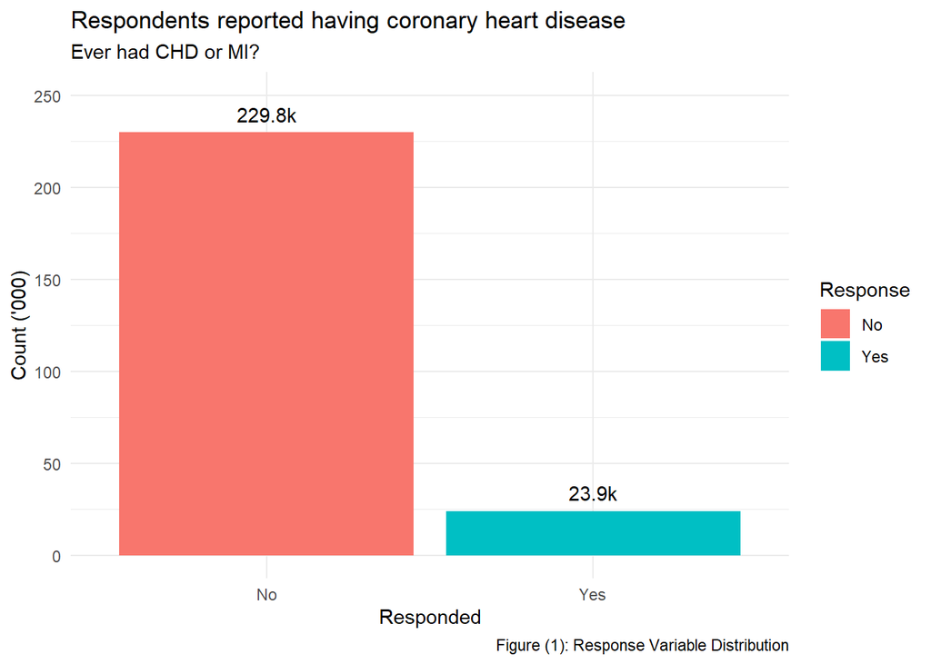

The dataset is very imbalanced with over 90% of cases being not having any CVD.

### Variables with low variance

```r
# #explore values with less than 5% variation
# colnames(dataX[,nearZeroVar(dataX, freqCut = 95/5, uniqueCut = 10)])
# x <- as.data.frame(dataX[,c('CholCheck', 'Stroke','AnyHealthcare', 'Diabetes.1')])
#
# featurePlot(x,
#             dataX$HeartDiseaseorAttack,
#             plot = 'density')
```

### investigate low information features

Perform Recursive Feature Elimination

```r
# subsets <- c( 5 )
# set.seed(3005)
#
# #use 50% of the dataset
# trainIndex <- createDataPartition(dataX$HeartDiseaseorAttack, p = 0.5, list = FALSE)
# rfe.train <- dataX[trainIndex,]
#
# #create Recursive Feature Elimination (rfe) to identify low importnat variables
# rfeCtrl <- rfeControl(functions = rfFuncs,
#                       method = "cv",
#                       verbose = FALSE)
# rfProfile <- rfe(x = rfe.train[,2:40],
#                 y = rfe.train[,1],
#                 sizes = subsets,
#                 rfeControl = rfeCtrl)
# rfProfile
# ggplot(rfProfile)
# plot(rfProfile)
# plot(rfProfile, metric = "Rsquared")
```

### correlation analysis

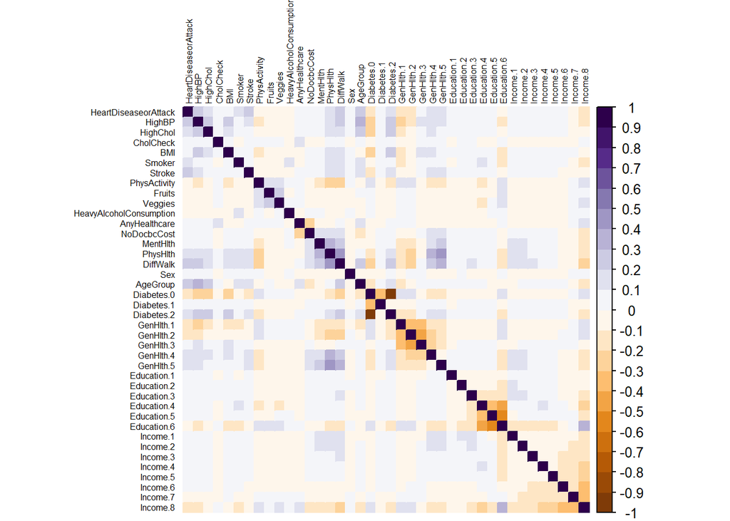

```r
#convert data to numeric in order to run correlations
  #convert to factor first to keep the integrity of the data - each value will become a number rather than turn into NA
  df_cor <- dataX
  df_cor <- df_cor %>% mutate_if(is.character, as.factor)
  df_cor <- df_cor %>% mutate_if(is.factor, as.numeric)
  #run a correlation and drop the insignificant ones
  corr <- cor(df_cor)

  #prepare to drop duplicates and correlations of 1
#  corr[lower.tri(corr,diag=TRUE)] <- NA
  #drop perfect correlations
  #corr[corr == 1] <- NA
  #turn into a 3-column table
  corr <- as.data.frame(as.table(corr))
  #remove the NA values from above
  corr <- na.omit(corr)

  #select significant values
#  corr <- subset(corr, abs(Freq) > 0.5)
  #sort by highest correlation
#  corr <- corr[order(-abs(corr$Freq)),]
  #print table
  #print(corr)

  #turn corr back into matrix in order to plot with corrplot
  mtx_corr <- reshape2::acast(corr, Var1~Var2, value.var="Freq")

  #plot correlations visually
  corrplot(mtx_corr,
           method ='color',
           is.corr=TRUE,
           tl.col="black",
           col = COL2('PuOr', 20),
           na.label=" ",
           number.cex = 0.5,
           tl.cex = 0.5)
```

as we see, there is a positive correlation between CVDs and high blood pressure, and negative correlation between healthy lifestyle variables and CVDs. This shows that people with active lifestyle and healthy diate are less likely to have CVD.

#### CVD and smoking

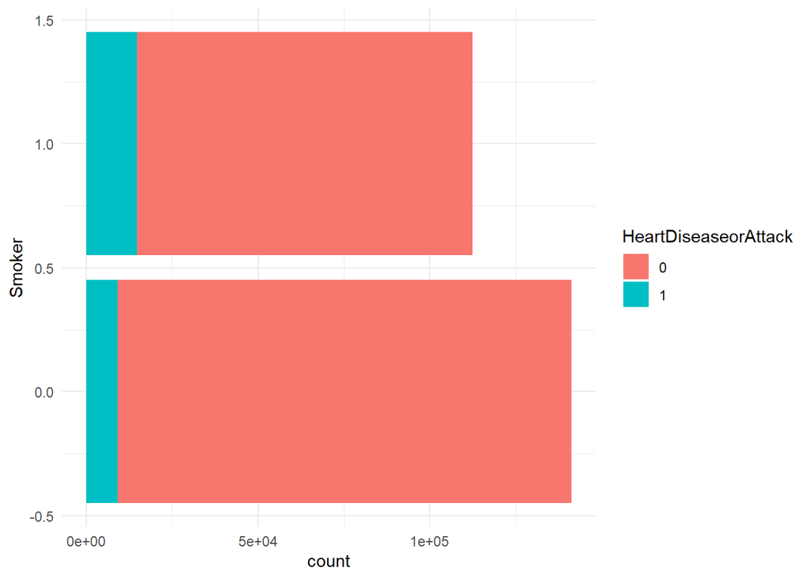

```r
#smokers are at more risk of having CVDs
hadHDA <-dataX[dataX$HeartDiseaseorAttack==1,]


ggplot(dataX, aes( y = Smoker, fill = HeartDiseaseorAttack))+
  geom_bar()+
  theme_minimal()
```

Smokers are more likely to have CVDs.

#### CVD and physical activity

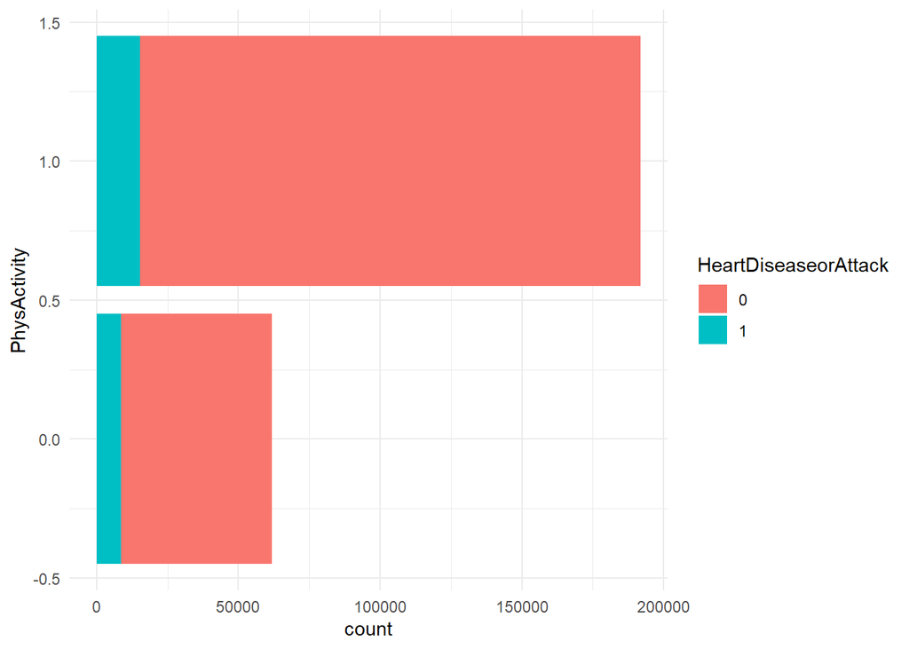

```r
#physical activity not necessarily prevent HDA
ggplot(dataX, aes( y = PhysActivity, fill = HeartDiseaseorAttack))+
  geom_bar()+
  theme_minimal()
```

#### CVD and Diabetes

```r
#Diabetics respondents are at more risk of being diagnosed with CDV
dataX %>%
  group_by(Diabetes.0,Diabetes.1,Diabetes.2,HeartDiseaseorAttack) %>%
  summarise(cnt = n()) %>%
  mutate(freq = formattable::percent(cnt / sum(cnt), 1))
```

```
## You can override using the `.groups` argument.
```

```
## # A tibble: 6 × 6
## # Groups:   Diabetes.0, Diabetes.1, Diabetes.2 [3]
##   Diabetes.0 Diabetes.1 Diabetes.2 HeartDiseaseorAttack    cnt freq
##        <dbl>      <dbl>      <dbl> <fct>                 <int> <formttbl>
## 1          0          0          1 0                     27468 77.7%
## 2          0          0          1 1                      7878 22.3%
## 3          0          1          0 0                      3967 85.7%
## 4          0          1          0 1                       664 14.3%
## 5          1          0          0 0                    198352 92.8%
## 6          1          0          0 1                     15351 7.2%
```

### CVD and BMI distribution

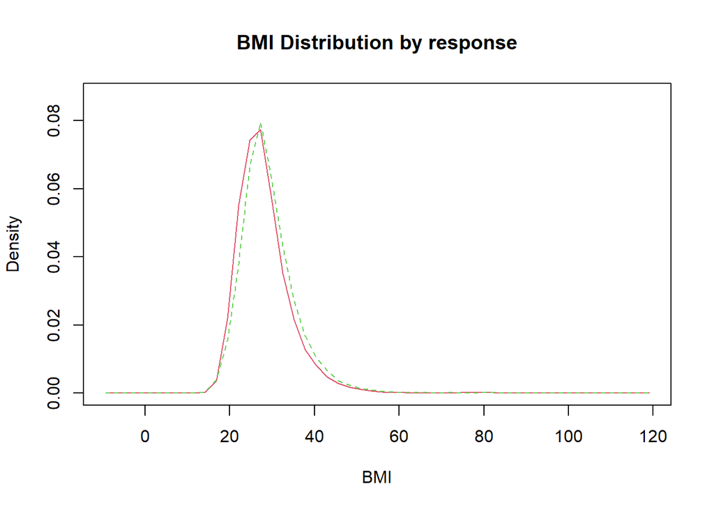

```r
sm.density.compare(org.BMI$BMI, org.BMI$HeartDiseaseorAttack, xlab="BMI")
  title(main="BMI Distribution by response")
```

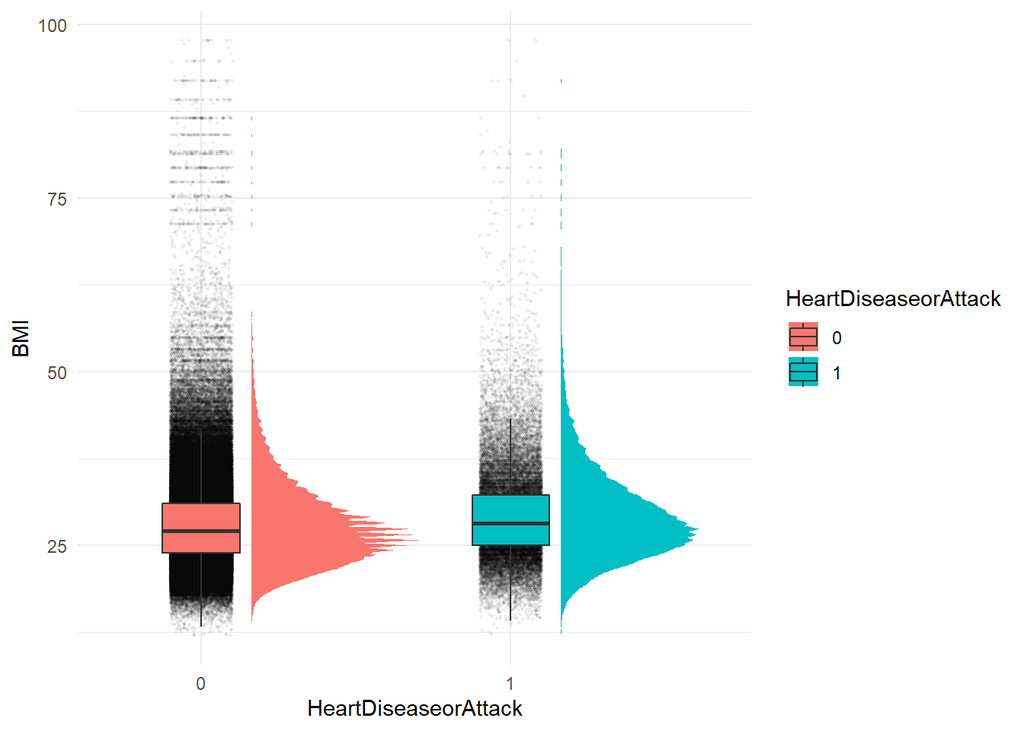

```r
## distribution
ggplot(org.BMI, aes(x = HeartDiseaseorAttack, y = BMI, fill = HeartDiseaseorAttack)) +
  ggdist::stat_halfeye(
    adjust = .5,
    width = .6,
    .width = 0,
    justification = -.3,
    point_colour = NA) +
  geom_point(
    size = 0.3,
    alpha = .05,
    position = position_jitter(
      seed = 5003, width = .1 )
  ) +
  geom_boxplot(
    width = .25,
    outlier.shape = NA
  ) + theme_minimal()+
  coord_cartesian(xlim = c(1.2, NA), clip = "off")
```

The overall of population in the database is overweight, however, people with CVD have a slightly higher BMI.

# Visualization t-SNE

```r
#
# # Use 10% of data to compute t-SNE
# tsne_subset <- 1:as.integer(0.01*nrow(data))
#
#
# #prep 50
# tsne50 <- Rtsne(data[tsne_subset,-c(1, 31)], perplexity = 50, theta = 0.5, pca = F, verbose = F, max_iter = 500, dims = 2, check_duplicates = F)
#
# classes <- as.factor(data$HeartDiseaseorAttack[tsne_subset])
# tsne_mat <- as.data.frame(tsne50$Y)
# prep50 <- ggplot(tsne_mat, aes(x = V1, y = V2)) + geom_point(aes(color = classes)) + theme_minimal() +  ggtitle("t-SNE prep = 50") + scale_color_manual(values = c("#E69F00", "#56B4E9"))
#
# #prep 100
# tsne100 <- Rtsne(data[tsne_subset,-c(1, 31)], perplexity = 100, theta = 0.5, pca = F, verbose = F, max_iter = 500, dims = 2, check_duplicates = F)
#
# classes <- as.factor(data$HeartDiseaseorAttack[tsne_subset])
# tsne_mat <- as.data.frame(tsne100$Y)
# prep100 <- ggplot(tsne_mat, aes(x = V1, y = V2)) + geom_point(aes(color = classes)) + theme_minimal() +  ggtitle("t-SNE prep = 100") + scale_color_manual(values = c("#E69F00", "#56B4E9"))
#
#
# #prep 500
# tsne500 <- Rtsne(data[tsne_subset,-c(1, 31)], perplexity = 500, theta = 0.5, pca = F, verbose = F, max_iter = 1000, dims = 2, check_duplicates = F)
#
# classes <- as.factor(data$HeartDiseaseorAttack[tsne_subset])
# tsne_mat <- as.data.frame(tsne500$Y)
# prep500 <- ggplot(tsne_mat, aes(x = V1, y = V2)) + geom_point(aes(color = classes)) + theme_minimal() +  ggtitle("t-SNE prep = 500") + scale_color_manual(values = c("#E69F00", "#56B4E9"))
#
# #prep 700
# tsne700 <- Rtsne(data[tsne_subset,-c(1, 31)], perplexity = 700, theta = 0.5, pca = F, verbose = F, max_iter = 5000, dims = 2, check_duplicates = F)
#
# classes <- as.factor(data$HeartDiseaseorAttack[tsne_subset])
# tsne_mat <- as.data.frame(tsne700$Y)
# prep700 <- ggplot(tsne_mat, aes(x = V1, y = V2)) + geom_point(aes(color = classes)) + theme_minimal() +  ggtitle("t-SNE prep = 700") + scale_color_manual(values = c("#E69F00", "#56B4E9"))
#
# grid.arrange(
#   prep50,
#   prep100,
#   prep500,
#   prep700,
#   nrow =2,
#   top = "Comparing tSNE prep"
# )
```

# Modeling Approach

Standard machine learning algorithms struggle with accuracy on imbalanced data for the following reasons:

ML algorithms struggle with accuracy because of the unequal distribution in dependent variable. This causes the performance of existing classifiers to get biased towards majority class. The algorithms are accuracy driven i.e. they aim to minimize the overall error to which the minority class contributes very little. ML algorithms assume that the data set has balanced class distributions. They also assume that errors obtained from different classes have same cost.

The methods to deal with this problem are widely known as ‘Sampling Methods’. Generally, these methods aim to modify an imbalanced data into balanced distribution using some mechanism. The modification occurs by altering the size of original data set and provide the same proportion of balance.

These methods have acquired higher importance after many researches have proved that balanced data results in improved overall classification performance compared to an imbalanced data set. Hence, it’s important to learn them. Firstly, the data will be split into training and test 80/20 respectivly. It is important to note that sampling techniques will only be applied to the training set and not the testing set.

```r
set.seed(5003)

inTrain <- createDataPartition(dataX$HeartDiseaseorAttack, p = 0.8)[[1]]
train <- dataX[ inTrain, ]
test <- dataX[-inTrain, ]
labels <- test$HeartDiseaseorAttack
paste0("training set include ",nrow(train)," observations (i.e. ",round(nrow(train)/nrow(dataX)*100,0),"% of total records)")
```

```
## [1] "training set include 202945 observations (i.e. 80% of total records)"
```

Secondly, below sampling methods will be used to treat the imbalanced dataset:

Undersampling Oversampling Synthetic Data Generation

### Undersampling

This method reduces the number of observations from majority class to make the data set balanced. This method is best to use when the data set is huge and reducing the number of training samples helps to improve run time and storage troubles.

Undersampling methods are of 2 types: Random and Informative.

Random undersampling method randomly chooses observations from majority class which are eliminated until the data set gets balanced. Informative undersampling follows a pre-specified selection criterion to remove the observations from majority class.

A possible problem with this method is that removing observations may cause the training data to lose important information pertaining to majority class.

```r
## Under sampling
set.seed(5003)

data_balanced_under <- ovun.sample(HeartDiseaseorAttack ~ ., data = train, method = "under")$data
```

### Oversampling

This method works with minority class. It replicates the observations from minority class to balance the data. Similar to undersampling, this method also can be divided into two types: Random Oversampling and Informative Oversampling.

Random oversampling balances the data by randomly oversampling the minority class. Informative oversampling uses a pre-specified criterion and synthetically generates minority class observations.

An advantage of using this method is that it leads to no information loss. The disadvantage of using this method is that, since oversampling simply adds replicated observations in original data set, it ends up adding multiple observations of several types, thus make the model more likely to overfit.

```r
## oversampling
set.seed(5003)

data_balanced_over <- ovun.sample(HeartDiseaseorAttack ~ ., data = train, method = "over")$data
```

### Synthetic Data Generation (SMOTE and ROSE)

In simple words, instead of replicating and adding the observations from the minority class, it overcome imbalances by generates artificial data. It is also a type of oversampling technique.

In regards to synthetic data generation, synthetic minority oversampling technique (SMOTE) is a powerful and widely used method. SMOTE algorithm draws artificial samples by choosing points that lie on the line connecting the rare observation to one of its nearest neighbors in the feature space. ROSE (random over-sampling examples) uses smoothed bootstrapping to draw artificial samples from the feature space neighbourhood around the minority class.

The modeling approach taking will involve training all classifiers on the train set with class imbalance suitably altered using each of the techniques above. The chosen model will be based on which technique and model yields the best ROC-AUC score on a holdout test set.

```r
set.seed(5003)

## ROSE
data_balanced_rose <- ROSE(HeartDiseaseorAttack ~ ., data  = train)$data

## SMOTE
data_balanced_smote <- smote(HeartDiseaseorAttack  ~ ., train)
```

# Data Preparation

# Logisitc Regression (glm)

Before we start using sampling let us first look at how glm performs with imbalanced data. We use the function roc.curve available in the ROSE package to gauge model performance on the test set

```r
#fit models
glm_fit <- glm(HeartDiseaseorAttack ~ ., data = train, family = 'binomial')
glm_fit_up <- glm(HeartDiseaseorAttack ~ ., data = data_balanced_over, family = 'binomial')
glm_fit_down <- glm(HeartDiseaseorAttack ~ ., data = data_balanced_under, family = 'binomial')
glm_fit_rose <- glm(HeartDiseaseorAttack ~ ., data = data_balanced_rose, family = 'binomial')
glm_fit_smote <- glm(HeartDiseaseorAttack ~ ., data = data_balanced_smote, family = 'binomial')



#predict models
pred_glm <- predict(glm_fit, newdata = test, type = 'response')
pred_glm_up <- predict(glm_fit_up, newdata = test, type = 'response')
pred_glm_down <- predict(glm_fit_down, newdata = test, type = 'response')
pred_glm_rose <- predict(glm_fit_rose, newdata = test, type = 'response')
pred_glm_smote <- predict(glm_fit_smote, newdata = test, type = 'response')
```

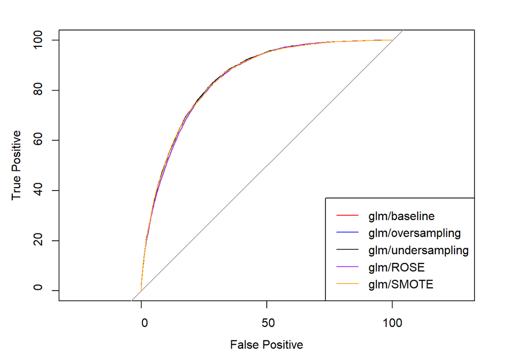

```r
#AUC
roc_pred_glm <- roc.curve(test$HeartDiseaseorAttack, pred_glm, plotit = FALSE)
roc_pred_glm_up <- roc.curve(test$HeartDiseaseorAttack, pred_glm_up, plotit = FALSE)
roc_pred_glm_down <- roc.curve(test$HeartDiseaseorAttack, pred_glm_down, plotit = FALSE)
roc_pred_glm_rose <- roc.curve(test$HeartDiseaseorAttack, pred_glm_rose, plotit = FALSE)
roc_pred_glm_smote <- roc.curve(test$HeartDiseaseorAttack, pred_glm_smote, plotit = FALSE)

# We evaluate the glm model performance on test data by visualising the roc score.
{par(pty = "m")
    roc(test$HeartDiseaseorAttack, pred_glm, plot=TRUE, legacy.axes = TRUE, percent = TRUE, xlab = "False Positive", ylab= "True Positive", col = 'red', lwd = 1)
    plot.roc(test$HeartDiseaseorAttack, pred_glm_up, percent = TRUE, col = 'blue', lwd = 1, add = TRUE)
    plot.roc(test$HeartDiseaseorAttack, pred_glm_down, percent = TRUE, col = 'black', lwd = 1, add = TRUE)
    plot.roc(test$HeartDiseaseorAttack, pred_glm_rose, percent = TRUE,  col = 'purple', lwd = 1, add = TRUE)
    plot.roc(test$HeartDiseaseorAttack, pred_glm_smote, percent = TRUE,  col = 'orange', lwd = 1, add = TRUE)
    legend("bottomright", legend =c("glm/baseline", "glm/oversampling", "glm/undersampling", "glm/ROSE", "glm/SMOTE"), col = c('red','blue','black','purple', 'orange'), lwd = 1)}
```

The ROC score is relatively the same across all different sampling techniques compared to the baseline model, therefore, we will use the baseline model.

## glm confusion matrix

```r
glm.roc.info <- roc(test$HeartDiseaseorAttack, pred_glm, legacy.axes=TRUE)
#choose the best cutoff point
glm.roc.df <- data.frame(
  tpp = glm.roc.info$sensitivities ,
  fpp = (1-glm.roc.info$specificities),
  thresholds = glm.roc.info$thresholds
  )

# 77% threshold
glm.cutoff <- min(glm.roc.df[glm.roc.df$tpp < 0.77 ,"thresholds"])
predicted <- as.factor(ifelse(pred_glm > glm.cutoff, 1, 0))
confusionMatrix(data =predicted, reference = test$HeartDiseaseorAttack, positive = "1")
```

```
## Confusion Matrix and Statistics
##
##           Reference
## Prediction     0     1
##          0 35168  1099
##          1 10789  3679
##
##                Accuracy : 0.7657
##                  95% CI : (0.762, 0.7694)
##     No Information Rate : 0.9058
##     P-Value [Acc > NIR] : 1
##
##                   Kappa : 0.2804
##
##  Mcnemar's Test P-Value : <2e-16
##
##             Sensitivity : 0.76999
##             Specificity : 0.76524
##          Pos Pred Value : 0.25429
##          Neg Pred Value : 0.96970
##              Prevalence : 0.09418
##          Detection Rate : 0.07251
##    Detection Prevalence : 0.28517
##       Balanced Accuracy : 0.76761
##
##        'Positive' Class : 1
##
```

```r
# visualise
glm.roc.coords <- coords(roc(test$HeartDiseaseorAttack, pred_glm), "all")
```

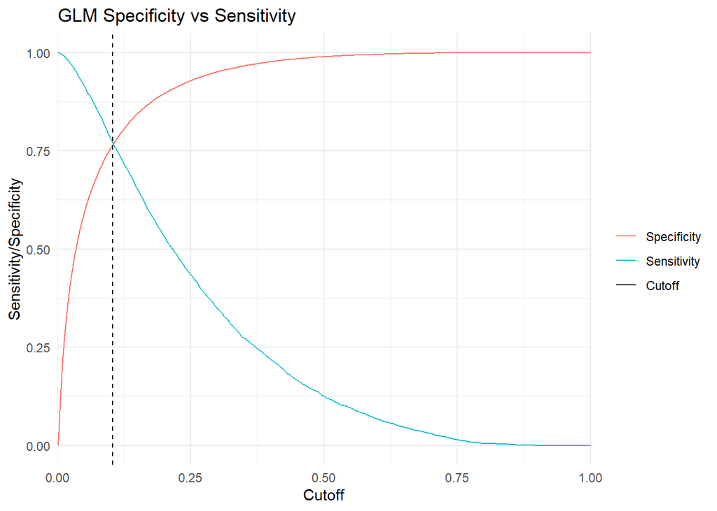

```r
ggplot(glm.roc.coords, aes(.data[["threshold"]])) +
  geom_line(aes(y = .data[['specificity']], colour = "Specificity")) +
  geom_line(aes(y = .data[['sensitivity']], colour = "Sensitivity")) +
  labs(title = "GLM Specificity vs Sensitivity",
              x = "Cutoff",
              y = "Sensitivity/Specificity"
       ) +
  scale_x_continuous(expand = c(0, 0), limits = c(0, 1))+
  geom_vline(xintercept =glm.cutoff, linetype="dashed",
                color = "black", size=0.5)+
  scale_color_manual(name = "", values = c( Specificity = "#F8766D", Sensitivity = "#00BFC4", Cutoff = 'black')) +

  ## change plot appearance
  theme_minimal()
```

## corss-validation with glm

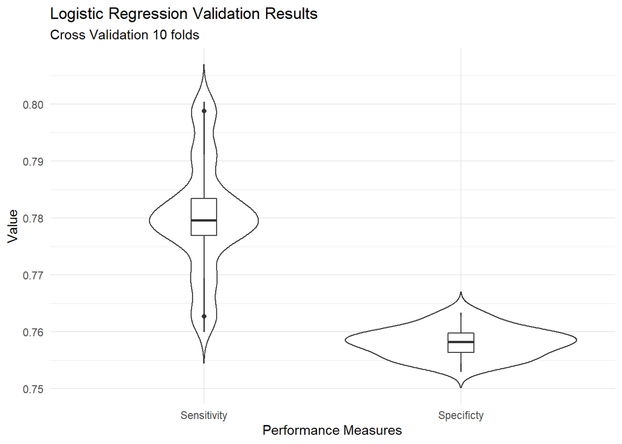

```r
# # create full model
# cv_glm_fit <- glm(HeartDiseaseorAttack ~ ., data = train, family = 'binomial')
# cv_glm_predicted <- as.factor(ifelse(cv_glm_fit$fitted.values > 0.1, 1, 0))
# confusionMatrix(data = cv_glm_predicted, reference = train$HeartDiseaseorAttack, positive = "1")
# roc.curve(train$HeartDiseaseorAttack, cv_glm_predicted, plotit = TRUE)
#
# roc(train$HeartDiseaseorAttack, cv_glm_fit$fitted.values, plot=TRUE, legacy.axes = TRUE, percent = TRUE, xlab = "False Positive", ylab= "True Positive", col = 'red', lwd = 1)

# apply 10-fold cross-validation to glm

set.seed(5003)
glm_fold <- createFolds(data[["HeartDiseaseorAttack"]], k = 10)

#create a function to split
splitterFunc <- function(x, data, n = nrow(data)){
  group = factor(ifelse(seq(n) %in% x, "Test", "Training"))
  split(data, group)
  }

X_train <- lapply(glm_fold, splitterFunc, data = data, n = nrow(data))

# build glm model
glmFun <- function(x, label.name = "HeartDiseaseorAttack"){
  cv_fit_glm <- glm(HeartDiseaseorAttack ~ .,
                     data = x$Training,
                     family = 'binomial')
  cv_predictions_glm <- predict(cv_fit_glm,
                         newdata = x$Test,
                         type = 'response')
  predictions <- as.factor(ifelse(cv_predictions_glm > 0.1, 1, 0))
  actuals <- x$Test[[label.name]]
  list(predictions = predictions, actuals = actuals)
}

glm.results <- lapply(X_train, glmFun)

#cv confusion matrix
ConfMatrix <- lapply(glm.results, function(x) confusionMatrix(x$predictions, x$actuals, positive = "1"))
#extracting TPP & TNP
cv_glm_Sensitivity <- vapply(ConfMatrix, function(x) x[["byClass"]][["Sensitivity"]], numeric(1))
cv_glm_Specificity <- vapply(ConfMatrix, function(x) x[["byClass"]][["Specificity"]], numeric(1))

cv_glm_Sensitivity <- data.frame( value = cv_glm_Sensitivity, ind = 'Sensitivity') #combine cv-scores
cv_glm_Specificity <- data.frame( value = cv_glm_Specificity, ind = 'Specificty') #combine cv-scores
cv_glm_scores  <- rbind(cv_glm_Sensitivity, cv_glm_Specificity)

#visualise measure results violin plot (for my liking)
ggplot(cv_glm_scores, aes(x = ind, y = value))  +
  geom_violin(trim=FALSE) +
  stat_summary(fun.data=mean_sdl) +
  theme_minimal() +
  geom_boxplot(width=0.1)+
  labs(title = "Logistic Regression Validation Results",
              subtitle = "Cross Validation 10 folds ",
              x = "Performance Measures", y = "Value",
  )
```

Logistic Regression avg. Sensitivity = 78% and Specificity = 75% with 10-fold cross validation

# Decision Trees (CART)

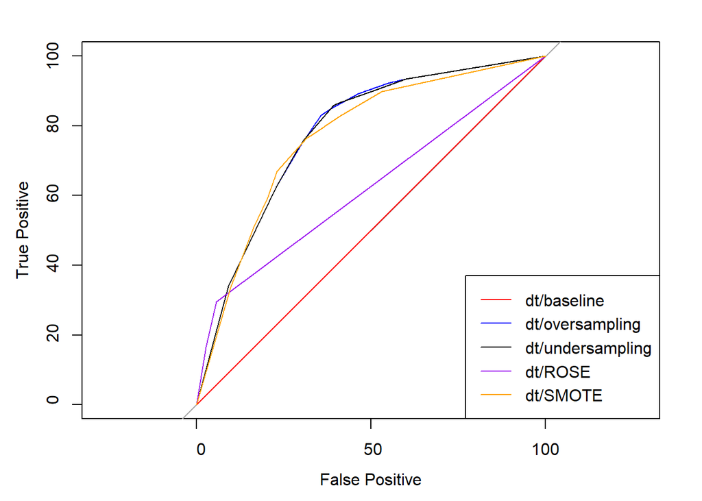

```r
#fit dt model
dt_fit <- rpart(HeartDiseaseorAttack ~ ., data = train)
dt_fit_up <- rpart(HeartDiseaseorAttack ~ ., data = data_balanced_over)
dt_fit_down <- rpart(HeartDiseaseorAttack ~ ., data = data_balanced_under)
dt_fit_rose <- rpart(HeartDiseaseorAttack ~ ., data = data_balanced_rose)
dt_fit_smote <- rpart(HeartDiseaseorAttack ~ ., data = data_balanced_smote)

#test model
pred_dt <- predict(dt_fit, newdata = test, method = "class")
pred_dt_up <- predict(dt_fit_up, newdata = test, method = "class")
pred_dt_down <- predict(dt_fit_down, newdata = test, method = "class")
pred_dt_rose <- predict(dt_fit_rose, newdata = test, method = "class")
pred_dt_smote <- predict(dt_fit_smote, newdata = test, method = "class")

#AUC
roc_pred_dt <- roc.curve(test$HeartDiseaseorAttack, pred_dt[,2], plotit = FALSE)$auc
roc_pred_dt_up <- roc.curve(test$HeartDiseaseorAttack, pred_dt_up[,2], plotit = FALSE)$auc
roc_pred_dt_down <- roc.curve(test$HeartDiseaseorAttack, pred_dt_down[,2], plotit = FALSE)$auc
roc_pred_dt_rose <- roc.curve(test$HeartDiseaseorAttack, pred_dt_rose[,2], plotit = FALSE)$auc
roc_pred_dt_smote <- roc.curve(test$HeartDiseaseorAttack, pred_dt_smote[,2], plotit = FALSE)$auc

#visualise AUC
{par(pty = "m")
    roc(test$HeartDiseaseorAttack, pred_dt[,2], plot=TRUE, legacy.axes = TRUE, percent = TRUE, xlab = "False Positive", ylab= "True Positive", col = 'red', lwd = 1)
    plot.roc(test$HeartDiseaseorAttack, pred_dt_up[,2], percent = TRUE, col = 'blue', lwd = 1, add = TRUE)
    plot.roc(test$HeartDiseaseorAttack, pred_dt_down[,2], percent = TRUE, col = 'black', lwd = 1, add = TRUE)
    plot.roc(test$HeartDiseaseorAttack, pred_dt_rose[,2], percent = TRUE,  col = 'purple', lwd = 1, add = TRUE)
    plot.roc(test$HeartDiseaseorAttack, pred_dt_smote[,2], percent = TRUE,  col = 'orange', lwd = 1, add = TRUE)
    legend("bottomright", legend =c("dt/baseline", "dt/oversampling", "dt/undersampling", "dt/ROSE", "dt/SMOTE"), col = c('red','blue','black','purple', 'orange'), lwd = 1)}
```

The baseline model for decision tree had a bad AUC score (50%), while both over/undersampling had an AUC score of 78%. We will use the DT model with undersampling to investigate the decision tree model

### dt paramter tunning

```r
# Exploring the model
printcp(dt_fit_down, digits = 3)
```

```
##
## Classification tree:
## rpart(formula = HeartDiseaseorAttack ~ ., data = data_balanced_under)
##
## Variables actually used in tree construction:
## [1] AgeGroup  DiffWalk  GenHlth.1 HighBP    HighChol  Sex
##
## Root node error: 19115/38244 = 0.5
##
## n= 38244
##
##       CP nsplit rel error xerror    xstd
## 1 0.3606      0     1.000  1.011 0.00512
## 2 0.0188      1     0.639  0.639 0.00477
## 3 0.0168      3     0.602  0.597 0.00468
## 4 0.0131      5     0.568  0.570 0.00462
## 5 0.0116      6     0.555  0.559 0.00459
## 6 0.0112      7     0.544  0.548 0.00456
## 7 0.0100      8     0.532  0.535 0.00453
```

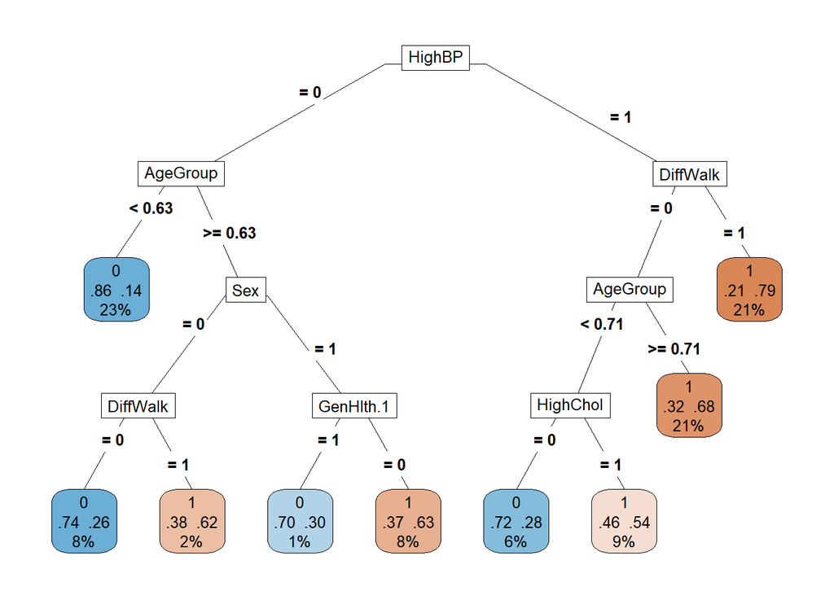

```r
#visualise decision tree
rpart.plot(dt_fit_down, roundint = TRUE,
box.palette = "BuBn", extra = 104,
type = 5, fallen.leaves = FALSE)
```

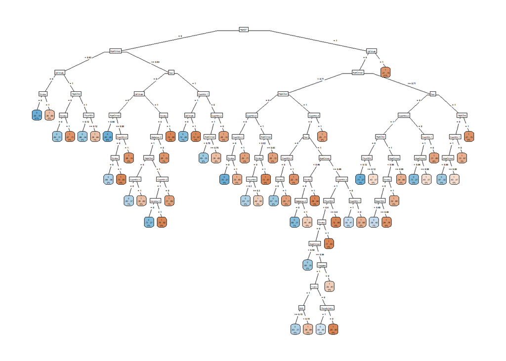

```r
# rpart hyperparameters tuning
dt.ctrl <- trainControl(method = "cv",
                        number = 10,
                        savePredictions = "final")
dt.fit.cv <- train(HeartDiseaseorAttack ~., data_balanced_under, method = 'rpart',
                   trControl = dt.ctrl,
                   tuneLength = 30)


#visualise cv model
rpart.plot(dt.fit.cv$finalModel, roundint = TRUE,
box.palette = "BuBn", extra = 104,
type = 5, fallen.leaves = FALSE)
```

```r
dt.predict.cv <- predict(dt.fit.cv, test)
confusionMatrix(table(test[,1], dt.predict.cv), positive = '1')
```

```
## Confusion Matrix and Statistics
##
##    dt.predict.cv
##         0     1
##   0 32380 13577
##   1   882  3896
##
##                Accuracy : 0.715
##                  95% CI : (0.7111, 0.7189)
##     No Information Rate : 0.6556
##     P-Value [Acc > NIR] : < 2.2e-16
##
##                   Kappa : 0.2374
##
##  Mcnemar's Test P-Value : < 2.2e-16
##
##             Sensitivity : 0.22297
##             Specificity : 0.97348
##          Pos Pred Value : 0.81540
##          Neg Pred Value : 0.70457
##              Prevalence : 0.34440
##          Detection Rate : 0.07679
##    Detection Prevalence : 0.09418
##       Balanced Accuracy : 0.59823
##
##        'Positive' Class : 1
##
```

```r
roc.curve(test$HeartDiseaseorAttack, dt.predict.cv, plotit = FALSE)$auc
```

```
## [1] 0.7599878
```

```r
print(dt.fit.cv)
```

```
## CART
##
## 38244 samples
##    39 predictor
##     2 classes: '0', '1'
##
## No pre-processing
## Resampling: Cross-Validated (10 fold)
## Summary of sample sizes: 34421, 34419, 34419, 34420, 34420, 34419, ...
## Resampling results across tuning parameters:
##
##   cp            Accuracy   Kappa
##   0.0003313279  0.7620285  0.5240736
##   0.0003662046  0.7615840  0.5231851
##   0.0004185195  0.7615056  0.5230294
##   0.0004708344  0.7612180  0.5224545
##   0.0005231494  0.7613749  0.5227689
##   0.0005754643  0.7609565  0.5219324
##   0.0006016218  0.7609303  0.5218799
##   0.0006800942  0.7599889  0.5199965
##   0.0007585666  0.7590214  0.5180607
##   0.0007847240  0.7590214  0.5180607
##   0.0008021624  0.7589691  0.5179560
##   0.0009416688  0.7575832  0.5151858
##   0.0009939838  0.7569556  0.5139323
##   0.0010462987  0.7568510  0.5137230
##   0.0012032435  0.7553869  0.5107925
##   0.0012555585  0.7543409  0.5086994
##   0.0012817159  0.7538441  0.5077057
##   0.0014648182  0.7527196  0.5054565
##   0.0016740779  0.7516736  0.5033633
##   0.0020402825  0.7501833  0.5003816
##   0.0036097306  0.7437248  0.4874671
##   0.0036882030  0.7422604  0.4845422
##   0.0046821868  0.7377104  0.4754482
##   0.0062777923  0.7346510  0.4693340
##   0.0111953963  0.7271728  0.4543831
##   0.0116139158  0.7236427  0.4473227
##   0.0130787340  0.7172632  0.4345496
##   0.0167930944  0.7106478  0.4212914
##   0.0187549045  0.6946965  0.3894089
##   0.3605545383  0.5874430  0.1747191
##
## Accuracy was used to select the optimal model using the largest value.
## The final value used for the model was cp = 0.0003313279.
```

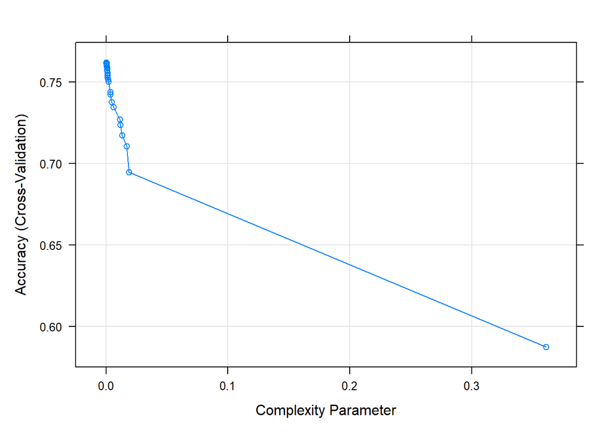

```r
plot(dt.fit.cv)
```

# Random Forest

```r
#split target from response
x = train[, -1]
y = train[,1]

x_up = data_balanced_over[, -1]
y_up = data_balanced_over[,1]

x_down = data_balanced_under[, -1]
y_down = data_balanced_under[,1]

x_rose = data_balanced_rose[, -1]
y_rose = data_balanced_rose[,1]

x_smote = data_balanced_smote[, -1]
y_smote = data_balanced_smote[,1]

#fit models
rf_fit <- Rborist(x, y, ntree = 1000, minNode = 20, maxLeaf = 13)
rf_fit_up <- Rborist(x_up, y_up, ntree = 1000, minNode = 20, maxLeaf = 13)
rf_fit_down <- Rborist(x_down, y_down, ntree = 1000, minNode = 20, maxLeaf = 13)
rf_fit_rose <- Rborist(x_rose, y_rose, ntree = 1000, minNode = 20, maxLeaf = 13)
rf_fit_smote <- Rborist(x_smote, y_smote, ntree = 1000, minNode = 20, maxLeaf = 13)

#predict test
rf_pred <- predict(rf_fit, test[,-1], ctgCensus = "prob")
rf_pred_up <- predict(rf_fit_up, test[,-1], ctgCensus = "prob")
rf_pred_down <- predict(rf_fit_down, test[,-1], ctgCensus = "prob")
rf_pred_rose <- predict(rf_fit_rose, test[,-1], ctgCensus = "prob")
rf_pred_smote <- predict(rf_fit_smote, test[,-1], ctgCensus = "prob")

prob <- rf_pred$prob
prob_up <- rf_pred_up$prob
prob_down <- rf_pred_down$prob
prob_rose <- rf_pred_rose$prob
prob_smote <- rf_pred_smote$prob

#AUC
roc.curve(test$HeartDiseaseorAttack, prob[,2], plotit = FALSE)
```

```
## Area under the curve (AUC): 0.829
```

```r
roc.curve(test$HeartDiseaseorAttack, prob_up[,2], plotit = FALSE)
```

```
## Area under the curve (AUC): 0.826
```

```r
roc.curve(test$HeartDiseaseorAttack, prob_down[,2], plotit = FALSE)
```

```
## Area under the curve (AUC): 0.828
```

```r
roc.curve(test$HeartDiseaseorAttack, prob_rose[,2], plotit = FALSE)
```

```
## Area under the curve (AUC): 0.822
```

```r
roc.curve(test$HeartDiseaseorAttack, prob_smote[,2], plotit = FALSE)
```

```
## Area under the curve (AUC): 0.808
```

# XGBoost

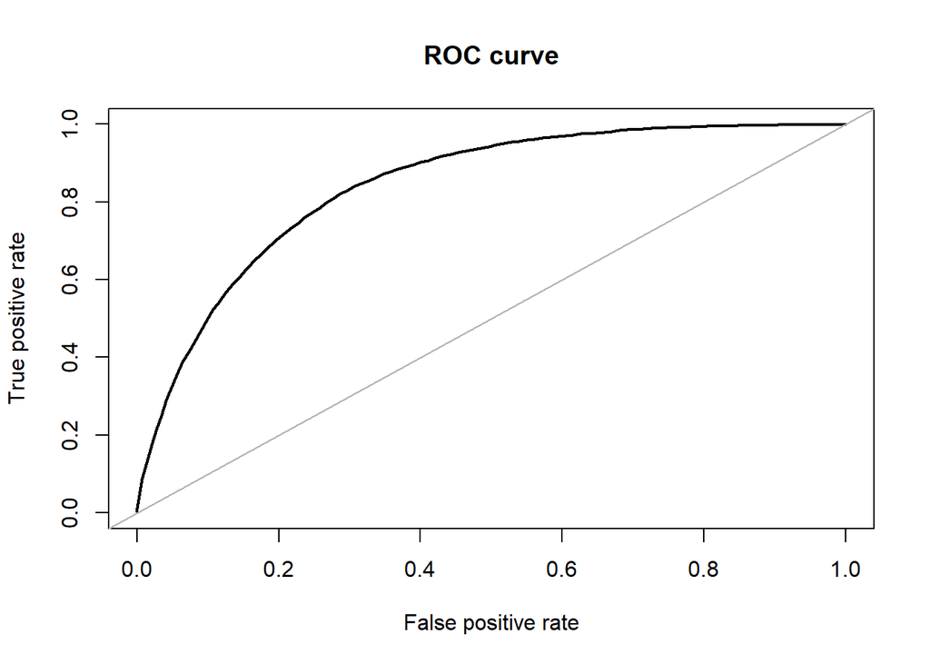

```
## Area under the curve (AUC): 0.841
```

```r
#prep
y = as.numeric(train$HeartDiseaseorAttack)-1
y_up = as.numeric(data_balanced_over$HeartDiseaseorAttack)-1
y_down = as.numeric(data_balanced_under$HeartDiseaseorAttack)-1
y_rose = as.numeric(data_balanced_rose$HeartDiseaseorAttack)-1
y_smote = as.numeric(data_balanced_smote$HeartDiseaseorAttack)-1

#model
xgb_fit <- xgboost(data = data.matrix(train[,-1]),
 label = y,
 eta = 0.1,
 gamma = 0.1,
 max_depth = 10,
 nrounds = 300,
 objective = "binary:logistic",
 colsample_bytree = 0.6,
 verbose = 0,
 nthread = 7,
)

xgb_fit_up <- xgboost(data = data.matrix(data_balanced_over[,-1]),
 label = y_up,
 eta = 0.1,
 gamma = 0.1,
 max_depth = 10,
 nrounds = 300,
 objective = "binary:logistic",
 colsample_bytree = 0.6,
 verbose = 0,
 nthread = 7,
)

xgb_fit_down <- xgboost(data = data.matrix(data_balanced_under[,-1]),
 label = y_down,
 eta = 0.1,
 gamma = 0.1,
 max_depth = 10,
 nrounds = 300,
 objective = "binary:logistic",
 colsample_bytree = 0.6,
 verbose = 0,
 nthread = 7,
)

xgb_fit_rose <- xgboost(data = data.matrix(data_balanced_rose[,-1]),
 label = y_rose,
 eta = 0.1,
 gamma = 0.1,
 max_depth = 10,
 nrounds = 300,
 objective = "binary:logistic",
 colsample_bytree = 0.6,
 verbose = 0,
 nthread = 7,
)

xgb_fit_smote <- xgboost(data = data.matrix(data_balanced_smote[,-1]),
 label = y_smote,
 eta = 0.1,
 gamma = 0.1,
 max_depth = 10,
 nrounds = 300,
 objective = "binary:logistic",
 colsample_bytree = 0.6,
 verbose = 0,
 nthread = 7,
)
#predict
xgb_pred <- predict(xgb_fit, data.matrix(test[,-1]))
xgb_pred_up <- predict(xgb_fit_up, data.matrix(test[,-1]))
xgb_pred_down <- predict(xgb_fit_down, data.matrix(test[,-1]))
xgb_pred_rose <- predict(xgb_fit_rose, data.matrix(test[,-1]))
xgb_pred_smote <- predict(xgb_fit_smote, data.matrix(test[,-1]))

#AUC
roc.curve(test$HeartDiseaseorAttack, xgb_pred, plotit = TRUE)
```

```r
roc.curve(test$HeartDiseaseorAttack, xgb_pred_up, plotit = FALSE)
```

```
## Area under the curve (AUC): 0.825
```

```r
roc.curve(test$HeartDiseaseorAttack, xgb_pred_down, plotit = FALSE)
```

```
## Area under the curve (AUC): 0.838
```

```r
roc.curve(test$HeartDiseaseorAttack, xgb_pred_rose, plotit = FALSE)
```

```
## Area under the curve (AUC): 0.842
```

```r
roc.curve(test$HeartDiseaseorAttack, xgb_pred_smote, plotit = FALSE)
```

```
## Area under the curve (AUC): 0.845
```

XGBoost with standard 84.1%

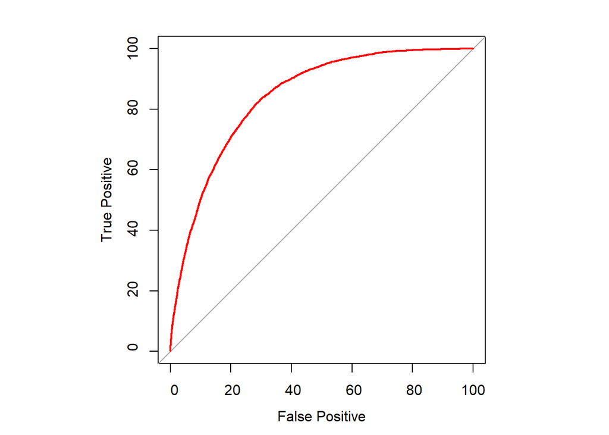

```r
#ROC Curve
par(pty = "s")
roc.info <- roc(test$HeartDiseaseorAttack, xgb_pred, plot=TRUE, legacy.axes = TRUE, percent = TRUE, xlab = "False Positive", ylab= "True Positive", col = 'red', lwd = 2)
```

```r
#choose the best cutoff point
roc.df <- data.frame(
  tpp = roc.info$sensitivities ,
  fpp = (1-roc.info$specificities),
  thresholds = roc.info$thresholds
  )

# 80% threshold
XGBoost.cutoff <- 1-max(roc.df[roc.df$tpp > 0.5 ,]$thresholds)
predicted <- as.factor(ifelse(xgb_pred > XGBoost.cutoff, 1, 0))
confusionMatrix(data =predicted, reference = test$HeartDiseaseorAttack)
```

```
## Confusion Matrix and Statistics
##
##           Reference
## Prediction     0     1
##          0 39943  1999
##          1  6014  2779
##
##                Accuracy : 0.8421
##                  95% CI : (0.8389, 0.8452)
##     No Information Rate : 0.9058
##     P-Value [Acc > NIR] : 1
##
##                   Kappa : 0.3275
##
##  Mcnemar's Test P-Value : <2e-16
##
##             Sensitivity : 0.8691
##             Specificity : 0.5816
##          Pos Pred Value : 0.9523
##          Neg Pred Value : 0.3160
##              Prevalence : 0.9058
##          Detection Rate : 0.7873
##    Detection Prevalence : 0.8267
##       Balanced Accuracy : 0.7254
##
##        'Positive' Class : 0
##
```

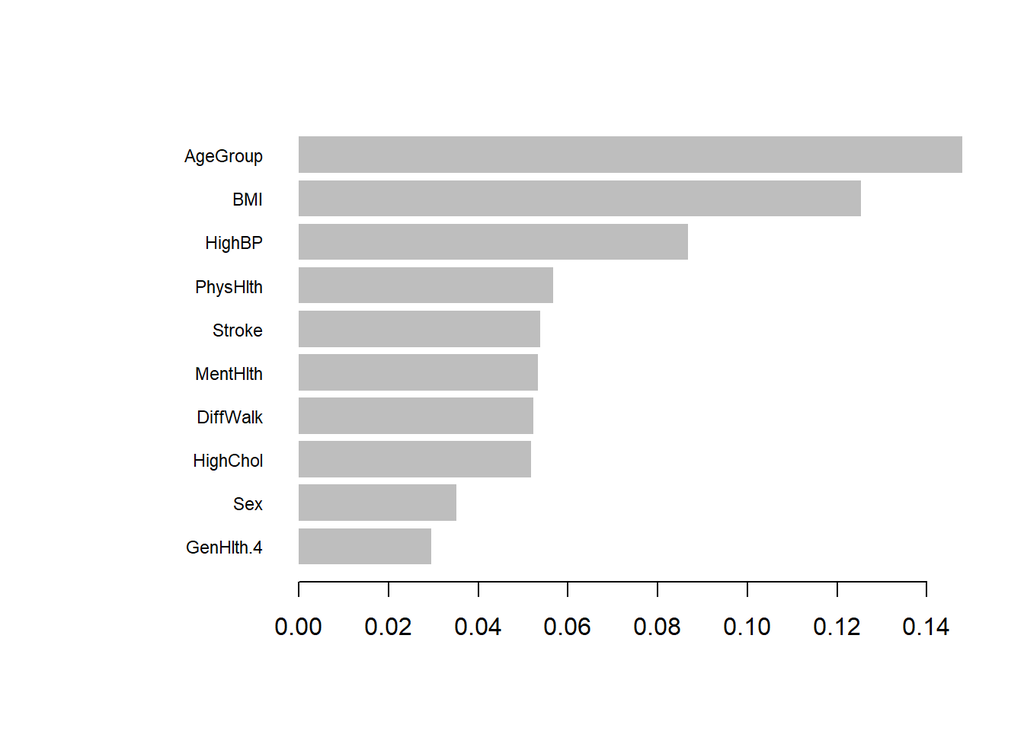

```r
names <- dimnames(data.matrix(train[,-1]))[[2]]

# Compute feature importance matrix
importance_matrix <- xgb.importance(names, model = xgb_fit)
# Nice graph
xgb.plot.importance(importance_matrix[1:10,])
```

#compare all models

```r
par(pty = "s")
roc(test$HeartDiseaseorAttack, xgb_pred, plot=TRUE, legacy.axes = TRUE, percent = TRUE, xlab = "False Positive", ylab= "True Positive", col = 'red', lwd = 1)
```

```
##
## Call:
## roc.default(response = test$HeartDiseaseorAttack, predictor = xgb_pred,     percent = TRUE, plot = TRUE, legacy.axes = TRUE, xlab = "False Positive",     ylab = "True Positive", col = "red", lwd = 1)
##
## Data: xgb_pred in 45957 controls (test$HeartDiseaseorAttack 0) < 4778 cases (test$HeartDiseaseorAttack 1).
## Area under the curve: 84.16%
```

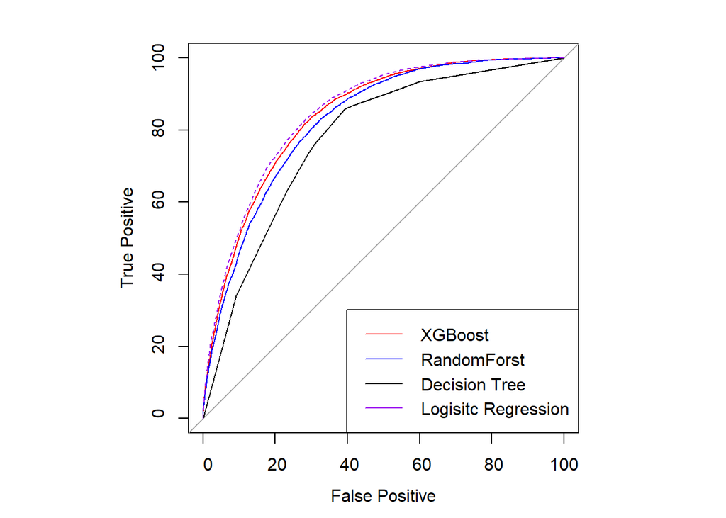

```r
plot.roc(test$HeartDiseaseorAttack, prob_up[,2], percent = TRUE, col = 'blue', lwd = 1, add = TRUE)
plot.roc(test$HeartDiseaseorAttack, pred_dt_down[,2], percent = TRUE, col = 'black', lwd = 1, add = TRUE)
plot.roc(test$HeartDiseaseorAttack, pred_glm_up, percent = TRUE,  col = 'purple', lwd = 1, lty = 2, add = TRUE)
legend("bottomright", legend =c("XGBoost", "RandomForst", "Decision Tree", "Logisitc Regression"), col = c('red','blue','black','purple'), lwd = 1)
```

Logistic regression combined with oversampling has the best ROC/AUC score.

# feature selections

```r
#
#   cv_fit_glm <- glm(HeartDiseaseorAttack ~ .,
#                      data = x$Training,
#                      family = 'binomial')
#   cv_predictions_glm <- predict(cv_fit_glm,
#                          newdata = x$Test,
#                          type = 'response')
#   predictions <- as.factor(ifelse(cv_predictions_glm > 0.1, 1, 0))
#   actuals <- x$Test[[label.name]]
#   list(predictions = predictions, actuals = actuals)
#
#
# #build function the stepwise function
# selectFeatureDirect <- function(train, test, features){
#
#   ## identify a feature to be selected
#   current.smallest.tpr <- Inf
#   selected.i <- NULL
#   for(i in seq(ncol(train))) {
#     current.f <- colnames(train)[i]
#
#     # Can't add features that are already in our list
#     if(current.f %in% c(features, "HeartDiseaseorAttack")) { next }
#     current.train <- cbind(train[, c(features, current.f, "HeartDiseaseorAttack")])
#
#     #fit model
#     model <- glm(HeartDiseaseorAttack ~ .,
#                      data = current.train,
#                      family = 'binomial')
#
#     #predict and calculate SME
#     current.test <- test[,c(features, current.f, "HeartDiseaseorAttack")]
#     pred.test <-
#             predict(model,
#                          newdata = current.test,
#                          type = 'response')
#     predictions.test <- as.factor(as.data.frame(ifelse(pred.test > 0.1, 1, 0))[,1])
#     actuals.test <- as.factor(current.test[["HeartDiseaseorAttack"]])
#     test.tpr <- confusionMatrix(data = predictions.test, reference = actuals.test, positive = "1")[["byClass"]][["Sensitivity"]]
#
#     #compare SME and update list
#     if(test.tpr < current.smallest.tpr) {
#         current.smallest.tpr <- test.tpr
#         selected.i <- colnames(train)[i]
#     }
#   }
#   return(selected.i)
# }
#
#
# features <- NULL
# # select the 1 to 5 best features using knn as a wrapper classifier
# for (j in 1:25) {
#   selected.i <- selectFeatureDirect(train, test, features)
#
#   # add the best feature from current run
#   features <- c(features, selected.i)
# }
#
# features
```

```r
#
# library(leaps)
# forward.credit <- regsubsets(HeartDiseaseorAttack ~ ., data = train,
#                            method = "forward", nvmax = 100)
# summary.forward.credit <- summary(forward.credit)
#
# min.cp <- which.min(summary.forward.credit$cp)
# plot(summary.forward.credit$cp[''], type = "l",
#      main = "Best subset selection- Mallows C_p",
#      ylab = "Mallows C_p measure",
#      xlab = "Number of features")
# points(summary.forward.credit$cp)
# points(min.cp, summary.forward.credit$cp[min.cp], pch = 4, col = "blue", cex = 2)
```